# Modelos Lineales Generalizados (GLM y GLMM) Presentado por Cesar Castro, Diana Garro y Sebastián Rojas

2024-01-18

# Introducción

Los modelos lineales generalizados (GLM) son extensiones de modelos de regresión lineal convencionales como: ANOVA, ANCOVA, regresión lineal, regresión de Poisson, regresión logística Estos fueron formulados por Nelder y Wedderburn en 1972 y luego por McCullagh y Nelder en 1989. Modelo que es útil cuando la distribución de la variable respuesta es categórica y/o numérica continua y que no es necesariamente normal, teniendo distribuciones de probabilidad de la familia exponencial (normal, gamma, binomial, poisson, multinomial, gaussiana). Además, con respecto a las variables predictoras el tipo de variable también es variado pues pueden ser categóricas, numéricas continuas o discretas, binarias, así como recuentos.

El modelo permite relacionar la variabilidad sistemática representada por las variables predictoras (modeladas linealmente entre sí para generar un predictor lineal) con la variabilidad aleatoria intrínseca de los datos representado en la variable respuesta (que posee una distribución en la familia exponencial). Por medio de la función de enlace, que lo transforma relacionando la media (de la variable respuesta) con una combinación lineal de las variables predictoras. Por otro lado, introduce otra función novedosa que modela la variación de los datos con los valores observados y usando la media, la cual es modelada en la función de enlace (entonces usa valores predichos por esta). De modo que con los valores observados de la variable respuesta se puede modelar, la media y la varianza.

# Supuestos del GLM:

- Independencia entre observaciones.
- Linealidad entre variables predictoras y respuesta mediante la función de enlace.
- La distribución del error de la variable respuesta debe ser la familia exponencial.
- No requiere homocedasticidad o normalidad en los errores.
- No hay valores particulares que influencien el ajuste del modelo.
- Las variables predictoras están relacionadas al fenómeno.

  No obstante, se puede manejar la dependencia entre observaciones con un modelo lineal generalizado mixto (GLMM), donde se introduce una función extra que modela la variabilidad no explicada por los predictores iniciales (fuentes de variación aleatoria entre observaciones), incorporando efectos aleatorios para contemplar la dependencia de observaciones. Esto permite extrapolar el modelo a casos datos con estructuras jerárquicas, longitudinales, agrupaciones de observaciones, de panel, estudios por sitios o unidades experimentales repetidas.

  Entonces se elabora el GLM seleccionando las variables explicativas de la variable respuesta de interés, cuya distribución de probabilidad pertenece a la familia exponencial y se determina cuál es en particular, con lo cual se puede elegir la función de enlace mas adecuada y que capture la variabilidad con la función de varianza.

# Ventajas y Desventajas

## Ventajas:

- Flexibles para una amplia variedad de datos. Útil en la amplia variedad de áreas y tipos de datos que se usan en biología.
- Fáciles de ajustar e interpretar. Lo cual lo hace una buena opción para biólogos que no están completamente adentrados en estadística.
- Se pueden hacer predicciones según los datos. Útil para comprender la relación entre variables o desarrollo de modelos para sistemas biológicos.

## Desventajas:

- Sensibilidad a valores atípicos. Entonces estos pueden tener un alto impacto en el análisis, aunque según el caso un buen manejo de datos soluciona este problema.
- Pueden llegar a ser difíciles de adaptar computacionalmente. A pesar de que el modelo se puede usar con datos que no cumplen la normalidad, regularmente no se usa en estos casos.
- No son apropiados para todos los tipos de datos.

# Algunos usos clásicos en biología:

- Los GLM se han utilizado para estudiar la relación entre la expresión génica y la enfermedad.
- Los GLM se han utilizado para estudiar la relación entre los factores ambientales y la enfermedad.
- Los GLM se han utilizado para estudiar la relación entre la dieta y la enfermedad.

**En general, los GLM son una herramienta poderosa que se puede utilizar para estudiar una amplia variedad de datos biológicos. Sin embargo, es importante conocer las limitaciones de los GLM antes de usarlos.**

# Interpretación de GLM y GLMM:

[video not shown]

# Ejemplo con ChickWeight

Se carga la librería *datasets* para trabajar la base de datos **ChickWeight**.

Se exploran los datos.

```
## Grouped Data: weight ~ Time | Chick
##   weight Time Chick Diet
## 1     42    0     1    1
## 2     51    2     1    1
## 3     59    4     1    1
## 4     64    6     1    1
## 5     76    8     1    1
## 6     93   10     1    1
```

```
##      weight           Time           Chick     Diet
##  Min.   : 35.0   Min.   : 0.00   13     : 12   1:220
##  1st Qu.: 63.0   1st Qu.: 4.00   9      : 12   2:120
##  Median :103.0   Median :10.00   20     : 12   3:120
##  Mean   :121.8   Mean   :10.72   10     : 12   4:118
##  3rd Qu.:163.8   3rd Qu.:16.00   17     : 12
##  Max.   :373.0   Max.   :21.00   19     : 12
##                                  (Other):506
```

## Evaluación inicial

### Distribución

Primero se debe saber que distribución tienen los datos, esto es necesario para que el modelo logre asiganr la función de enlace.

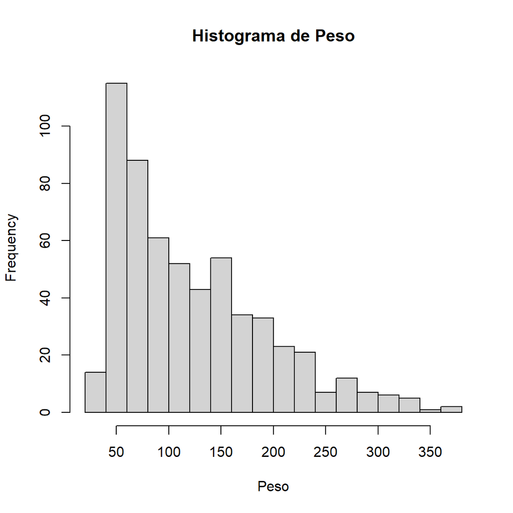

La distribución es asimétrica positiva, por lo tanto se debe usar el modelo “Gamma”. Si los datos fueran asimétricos negativos se debe usar Tweedie. En caso de que la distribución sea normal, lo correcto es usar la Gaussian.

### Supuesto de independencia

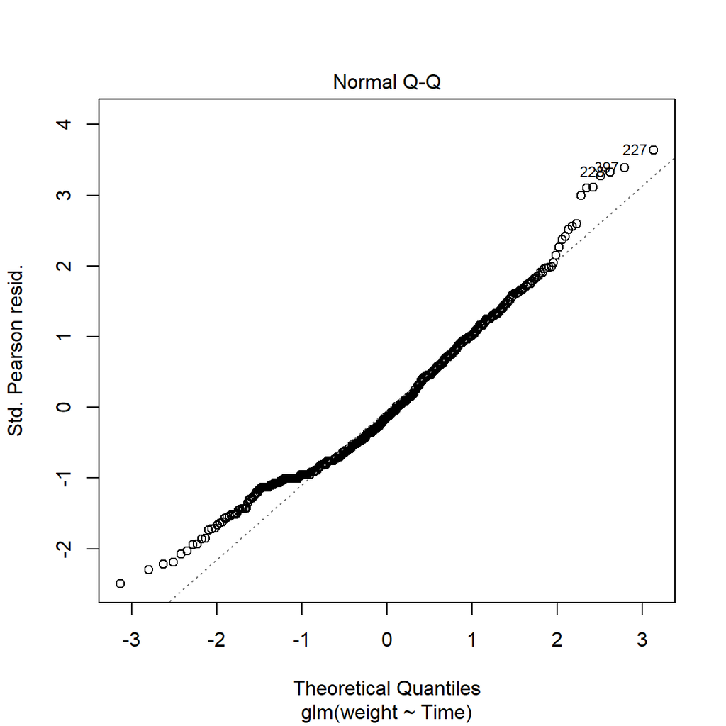

```r
# Se ajusta el GLM
glm_model <- glm(weight ~ Time, data = ChickWeight, family = Gamma)
# Gráfico de residuos estandarizados vs. orden de las observaciones sin ajustar el modelo
plot(glm_model, which = 2)
```

### Variables predictoras relacionadas con la variable respuesta

Se calcula la relación de las variables predictoras candidatas con la variable respuesta.

```
## Correlación entre tiempo y peso: 0.8371017
```

```
## Correlación entre dieta y peso: 0.2081957
```

El valor de correlación estará entre -1 y 1, donde un valor cercano a 1 indica una correlación positiva fuerte, un valor cercano a -1 indica una correlación negativa fuerte, y un valor cercano a 0 indica una correlación débil o nula.

## Aplicación del modelo GLMM

```r
library(lme4)
library(lmerTest)

# Cargar los datos
data(ChickWeight)

# Ajustar el GLMM
glmm_model <- glmer(weight ~ Time + Diet + (1 | Chick), data = ChickWeight, family = Gamma)
```

### Supuestos

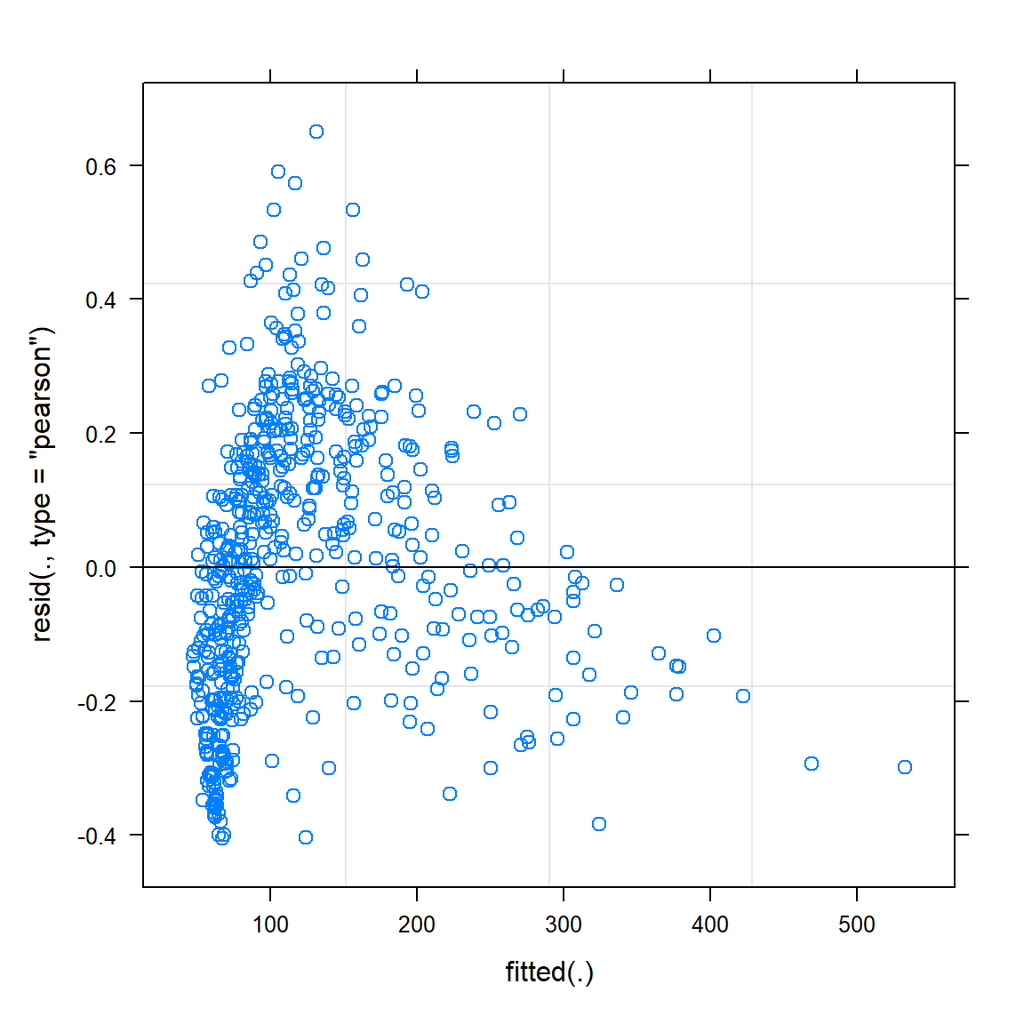

```r
plot(glmm_model, which = 1)
```

Resuduos estandarizados vrs predicciones ajustadas. Cuando los puntos se distribuyen aleatoriamente alrededor de la línea recta, indica una relación lineal adecuada entre las variables. Si hay patrones sistemáticos, se deben transformar las variables o usar modelos alternativos.

### Distribución de la variable respuesta

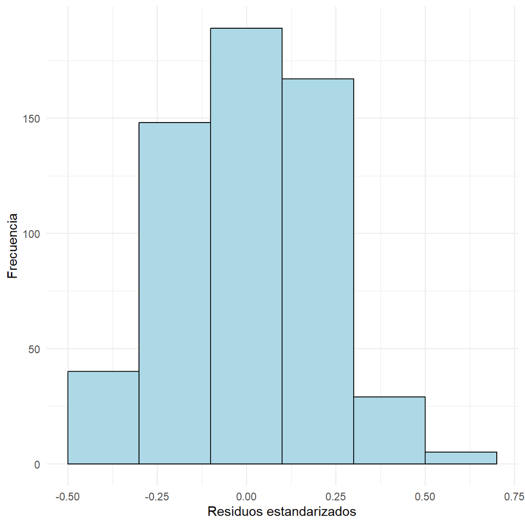

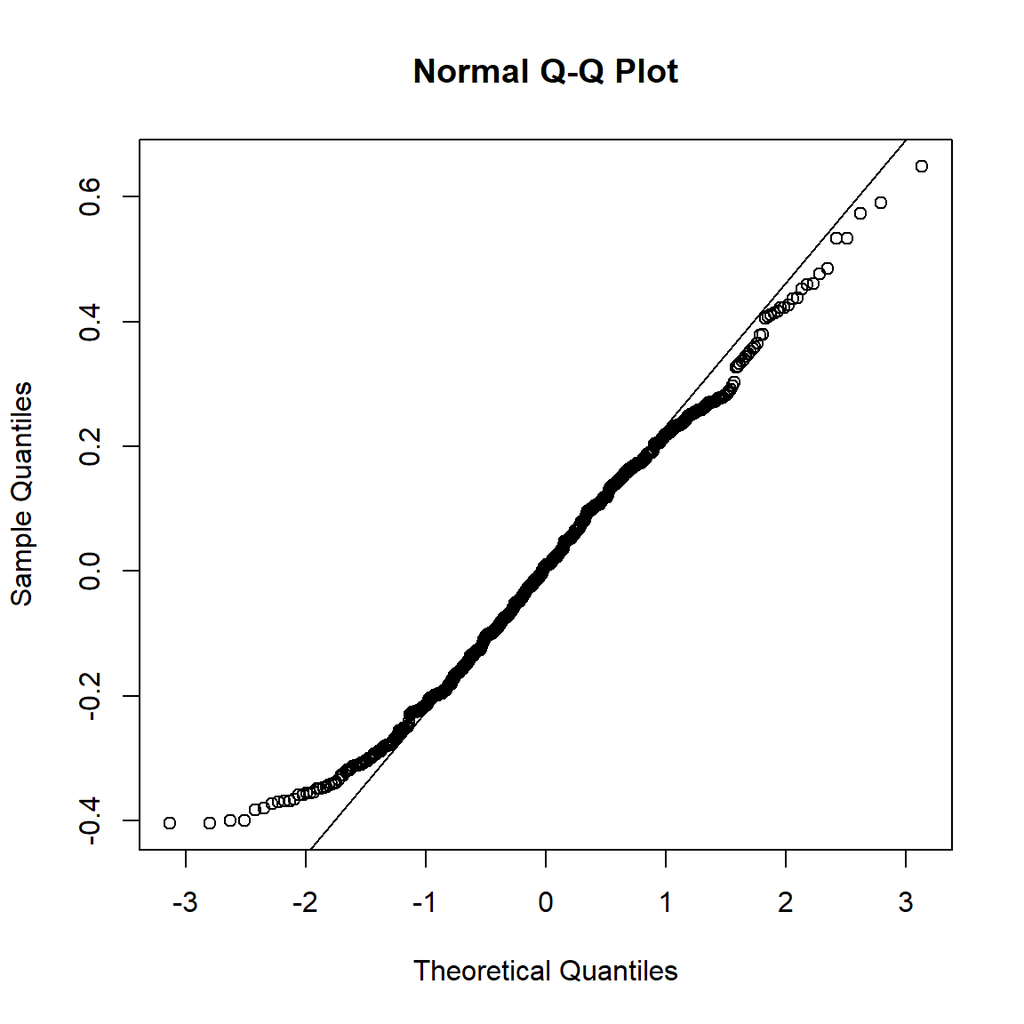

Si la distribución de los residuos se asemeja a una distribución exponencial, esperaríamos ver una forma simétrica y un pico alrededor de cero. Si hay desviaciones importantes de esta forma, podría indicar una violación del supuesto de distribución. Un QQ plot compara la distribución de los valores observados (en este caso, los residuos) con una distribución teórica (la distribución normal en este caso). Si los residuos siguen una distribución exponencial, esperaríamos ver que los puntos en el gráfico se ajustan aproximadamente a una línea recta. Desviaciones notables de esta línea recta podrían indicar una violación del supuesto de distribución.

## Análisis de los datos

[figure not shown]

# Uso de GLM y GLMM en ciencias biológicas:

[video not shown]

# Conclusiones

Los GLM y los GLMM son potentes herramientas estadísticas que se pueden utilizar para analizar una amplia variedad de datos en ciencias biológicas. Son útiles porque se pueden usar para modelar una amplia variedad de datos, incluidos datos de conteo, datos binarios, datos ordinales y datos longitudinales. También se pueden usar para modelar datos agrupados o repetidos. Esto los convierte en una herramienta valiosa para comprender las relaciones entre diferentes variables y extraer información relevante para un fin específico, derivada datos complejos.

# Referencias

- Diantina, S., McGill, C., Millner, J., Nadarajan, J., W. Pritchard, H., & Clavijo McCormick, A. (2020). Comparative seed morphology of tropical and temperate orchid species with different growth habits. Plants, 9(2), 161.
- Lambert, I., Paysant-Le Roux, C., Colella, S., & Martin-Magniette, M. L. (2020). DiCoExpress: a tool to process multifactorial RNAseq experiments from quality controls to co-expression analysis through differential analysis based on contrasts inside GLM models. Plant Methods, 16, 1-10.
- Nakanishi, H., Yasui, K., Ikehara, Y., Yokoyama, H., Munesue, S., Kodera, Y., & Tatematsu, M. (2005). Establishment and characterization of three novel human gastric cancer cell lines with differentiated intestinal phenotype derived from liver metastasis. Clinical & experimental metastasis, 22, 137-147.
- Skern-Mauritzen, M., Lindstrøm, U., Biuw, M., Elvarsson, B., Gunnlaugsson, T., Haug, T., … & Víkingsson, G. (2022). Marine mammal consumption and fisheries removals in the Nordic and Barents Seas. ICES Journal of Marine Science, 79(5), 1583-1603.
- Rasch, D., Verdooren, R., & Pilz, J. (2019). Applied statistics: theory and problem solutions with R. John Wiley & Sons.
- McCullagh, P. (2019). Generalized linear models. Routledge.
- Hardin, J. W., Hardin, J. W., Hilbe, J. M., & Hilbe, J. (2007). Generalized linear models and extensions. Stata press.